# Mi primera pagina web en Rmarkdown

Abraham Zamudio

2023-02-15

# Introduccion a Rmarkdown

La forma de estructurar un documento o de crear secciones de Latex (H1 en HTML) es lo que me va permitir estructurar mi documento.

UN archivo de codigo *R MarkDown* (`.Rmd`), va servir para escribir nuestros reportes combinando codigo con text

El codigo usando el lenguaje de programacion `R` se agregar por intermedio de pedazos de codigo (*code chunks*)

```r
# Esto es un comentario de R
# Una de las primeras cosas que aprendimos es a configurar
# nuestro directorio de trabajo
setwd("C://Users/azamudio/Desktop/Programacion_R/Sesion6/")
```

Luego de conocer como definir nuestro directorio de trabajo y saber como verificar (`getwd`), podemos concentrarnos en aprender a realizar operaciones aritmeticas.

```r
# Usemos el operador exponenciacion
2^8
```

```
## [1] 256
```

Agreguemos un grafico usando `R` a nuestro reporte

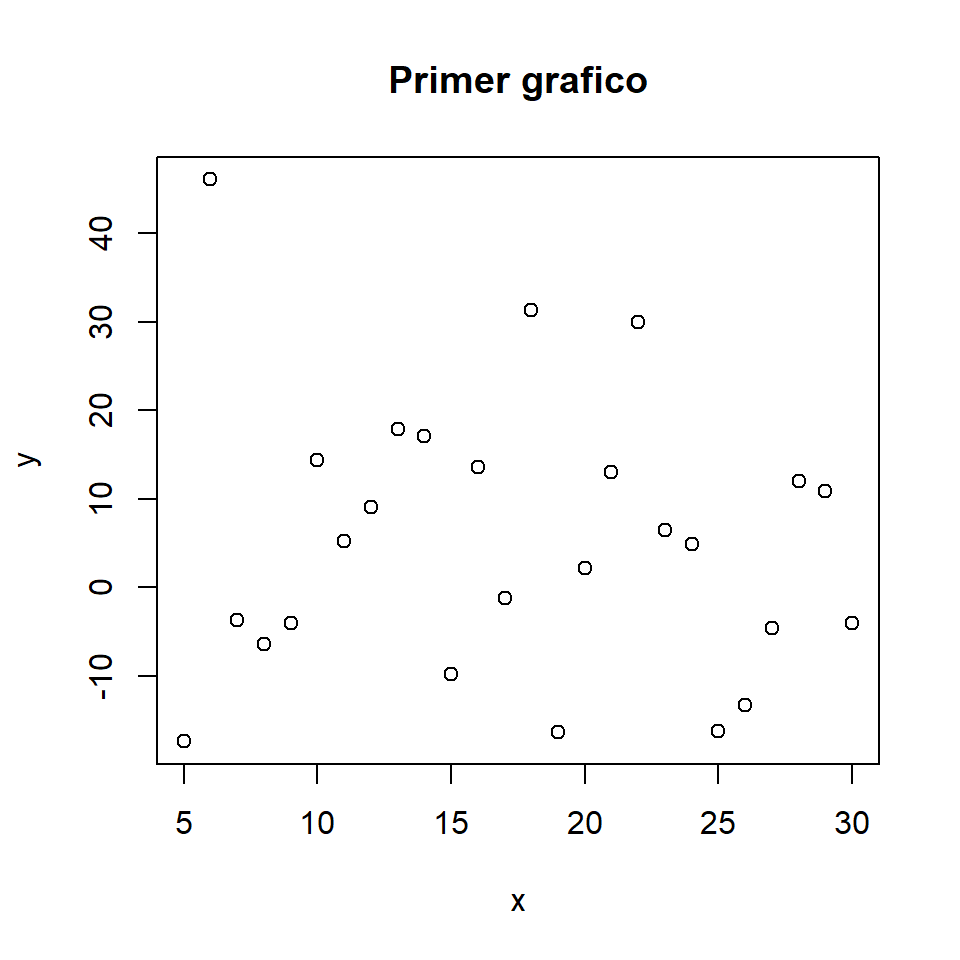

```r
# Definamos una variable independiente
x <- 5:30

# Definamos una variable dependiente
y <- rnorm(n = length(x), mean = 3.6, sd  = 12.5)

# Usemos el paquete graphics para mostrar un diagrama de dispersion
plot(x,y,main = "Primer grafico")
```

# Formato del texto en mi reporte

Algunas de las formas mas comunes de manipular cualquier texto son :

- *cursiva*
- **formato en negritas**
- *curviva y en negritas*
- Texto erroneo
- [Univirtual](https://univirtual.uni.pe/)
- `codigo_en_lenguaje_R <- PIT2023`

Tambien (y al igual que en HTML y de manera similar a LaTeX) podemos tener una jerarquia entre titulos, subtitulos, y demas elementos internos.

# Primer Titulo (`# Primer Titulo`) :

Esto es equivalente a un `\section` de LaTeX o a un `H1` de HTML.

## Primer subtitulo (`## Primer subtitulo`)

### Elemento interno al primer subtitulo

#### Elemento interno al anterior :

Equivalente al H4 de HTML

##### Titulo INterno H5

###### Titulo interno H6

# Codigo LaTeX

Este lenguaje de marcado tambien soporta algo de codigo $\LaTeX$. Es ya sabido que $\LaTeX$ es muy bueno para agregar formular/operaciones con objetos matematicos tanto en una linea , como por ejemplo $a^2 + b^2 = c^2$, asi como en un parrafo/linea dedicado

$$\lim_{x \to 0} \frac{\sin(x)}{x} =
1$$